# Reproducible Research: Peer Assessment 1

```r
# Loading required libraries for this study
library(dplyr)
library(ggplot2)
```

## Loading and preprocessing the data

```r
# This script assumes that activity.zip is available in the current directory
unzip("activity.zip")

activityData <- tbl_df(read.csv("activity.csv", header = TRUE)) %>%
    mutate(day = as.Date(date))
```

## What is the mean total number of steps taken per day?

First we calculate the total number of steps taken per day.

```r
# Summarize total of steps by day
totalStepsByDay <- activityData %>%
    group_by(day) %>%
    summarize(total_steps = sum(steps, na.rm = TRUE))
```

Then we make a histogram of the total number of steps taken each day.

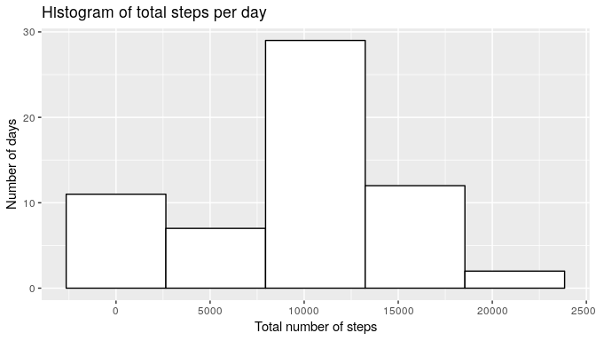

```r
ggplot(totalStepsByDay, aes(total_steps)) +
    geom_histogram(na.rm = TRUE, bins = 5, color = "black", fill = "white") +
    labs(title = "Histogram of total steps per day",
         x = "Total number of steps",
         y = "Number of days")
```

Next we calculate and report the mean and median.

```r
meanStepsPerDay <- mean(totalStepsByDay$total_steps, na.rm = TRUE)
medianStepsPerDay <- median(totalStepsByDay$total_steps, na.rm = TRUE)
```

Ignoring missing values, the **mean** of the total number of steps taken per day was **9354.23** while the **median** was **10395**.

## What is the average daily activity pattern?

We summarize the data by the 5-minute interval.

```r
# Summarize total of steps by the interval
meanStepsByInterval <- activityData %>%
    group_by(interval) %>%
    summarize(mean_steps = mean(steps, na.rm = TRUE)) %>%
    mutate(interval_time =
               as.POSIXct(strptime(sprintf("%04d", interval),
                                   format = "%H%M")))
```

Then we make a time series plot of the average number of steps taken on each 5-minute interval.

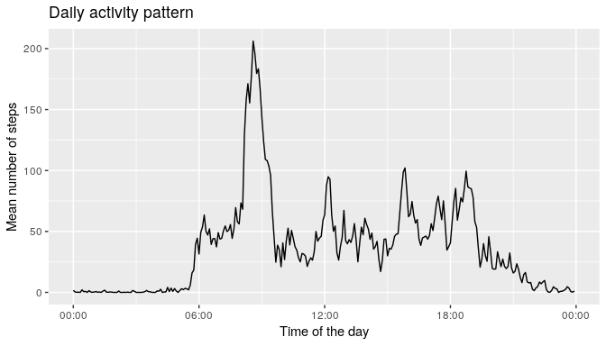

```r
ggplot(meanStepsByInterval, aes(interval_time, mean_steps)) +
    geom_line(na.rm = TRUE) +
    scale_x_datetime(date_labels = "%H:%M") +
    labs(title = "Daily activity pattern",
         x = "Time of the day",
         y = "Mean number of steps")
```

```r
mostActiveInterval <- filter(meanStepsByInterval, mean_steps == max(mean_steps))
stepsInMostActiveInterval <- mostActiveInterval$mean_steps
mostActiveTime <- format.Date(mostActiveInterval$interval_time, "%H:%M")
```

On average across all days in the dataset, the **most active 5-minute interval** is the one that starts at **08:35**, with an average of **206.17** steps taken.

## Imputing missing values

Calculate the number of missing values in the dataset.

```r
rowsWithNA <- sum(!complete.cases(activityData))
missingSteps <- sum(is.na(activityData$steps))
missingDate <- sum(is.na(activityData$date))
missingInterval <- sum(is.na(activityData$interval))
```

We see that there are **2304** rows with missing values. In particular, we have 2304 missing values on the steps variable, 0 missing from date and 0 missing from interval.

We create a new dataset in which we **replace those missing values for the mean steps (across all days) taken on the corresponding 5-minute interval**.

```r
# Function that returns steps if not missing, or else the mean for the interval
getMeanStepsForIntervalIfMissing <- function(steps, interval) {
    if (is.na(steps)) {
        meanStepsByInterval[meanStepsByInterval$interval == interval, ]$mean_steps
    } else {
        steps
    }
}

# Replaces missing data on a new dataset using the function defined above
activityDataImputed <- activityData %>%
    mutate(steps = mapply(getMeanStepsForIntervalIfMissing,
                          activityData$steps,
                          activityData$interval))

totalStepsByDayImputed <- activityDataImputed %>%
    group_by(day) %>%
    summarize(total_steps = sum(steps, na.rm = TRUE))
```

Now we compare with the original dataset to assess the impact. First, comparing the histogram of the total number of steps taken each day.

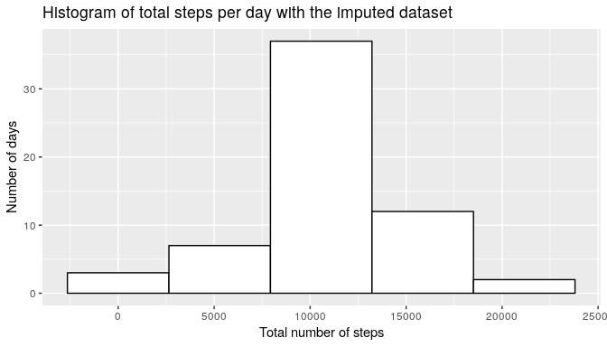

```r
ggplot(totalStepsByDayImputed, aes(total_steps)) +
    geom_histogram(na.rm = TRUE, bins = 5, color = "black", fill = "white") +
    labs(title = "Histogram of total steps per day with the imputed dataset",
         x = "Total number of steps",
         y = "Number of days")
```

Now for the mean and median.

```r
meanStepsPerDayImputed <- mean(totalStepsByDayImputed$total_steps, na.rm = TRUE)
medianStepsPerDayImputed <- median(totalStepsByDayImputed$total_steps, na.rm = TRUE)
```

With imputed data, the mean of the total number of steps taken per day changed from **9354.23** to **10766.19** while the median changed from **10395** to **10766.19**.

We see that the impact of imputing missing data is relatively strong, but we are confident with the strategy and will proceed with the analysis with imputed data.

## Are there differences in activity patterns between weekdays and weekends?

We create a new factor variable day_type with the values “weekday” or “weekend” to analyse changes in activity levels in the weekend.

```r
# Function to return type of the day
dayType <- function(day) {
    if (weekdays(day) %in% c("Saturday", "Sunday")) {
        "weekend"
    } else {
        "weekday"
    }
}

# Create new variable using the function defined above
activityDataImputed <- activityDataImputed %>%
    mutate(day_type = as.factor(sapply(day, dayType)))
```

We then make a time series plot comparing the average number of steps taken on each 5-minute interval, on weekdays and on weekends.

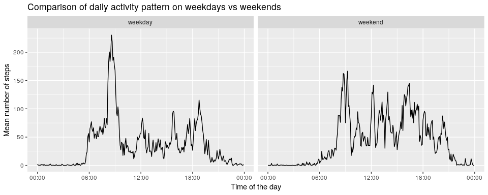

```r
# Summarize total of steps by the interval, grouped by day_type
meanStepsByIntervalImputed <- activityDataImputed %>%
    group_by(interval, day_type) %>%
    summarize(mean_steps = mean(steps, na.rm = TRUE)) %>%
    mutate(interval_time =
               as.POSIXct(strptime(sprintf("%04d", interval),
                                   format = "%H%M")))

ggplot(meanStepsByIntervalImputed, aes(interval_time, mean_steps)) +
    geom_line(na.rm = TRUE) +
    facet_grid(. ~ day_type) +
    scale_x_datetime(date_labels = "%H:%M") +
    labs(title = "Comparison of daily activity pattern on weekdays vs weekends",
         x = "Time of the day",
         y = "Mean number of steps")
```

When we split the data in weekdays vs weekends, we can see that there are different patterns of daily activity, namely we can se more activity in the morning on weekdays and more activity in the evening on weekends.